# Feeagh discharge and water balance estimate

#### Mill Race and Salmon Leap Flows

```python
import IPython.core.display as di
di.display_html('<button onclick="jQuery(\'.input_area\').toggle();jQuery(\'.prompt\').toggle();">Toggle code</button>', raw=True)
```

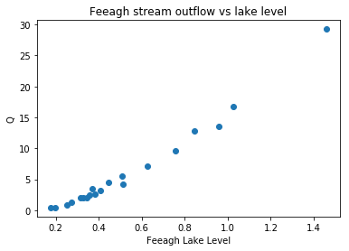

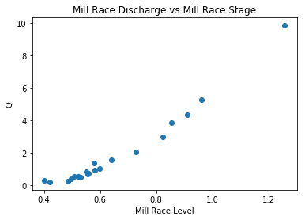

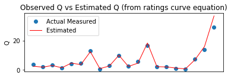

```python
 import numpy as np
data = np.genfromtxt('/Users/seankelly/Desktop/Temp_WD/Burrishoole river flow into Furnace_SK.csv', delimiter=',')
import matplotlib.pyplot as plt
Q = data[:,3]
FeeaghLevel = data[:,4]
fig1 = plt.figure()
ax1 = fig1.add_subplot(111)
ax1.plot(FeeaghLevel,Q,'o')
plt.title('Feeagh stream outflow vs lake level')
plt.ylabel('Q')
plt.xlabel('Feeagh Lake Level')

MR_Q = data[:,1]
MR_Level = data[:,5]
fig1 = plt.figure()
ax1 = fig1.add_subplot(111)
ax1.plot(MR_Level,MR_Q,'o')
plt.title('Mill Race Discharge vs Mill Race Stage')
plt.ylabel('Q')
plt.xlabel('Mill Race Level')

# Make plots
Q_est = data[:,6]
fig = plt.figure()
ax1 = fig.add_subplot(211)
plt.plot(Q, 'o')
plt.plot(Q_est, 'r-',linewidth=1)
plt.ylabel("Q")
plt.legend(['Actual Measured','Estimated'])
plt.title("Observed Q vs Estimated Q (from ratings curve equation)")
ax1.axes.get_xaxis().set_visible(False)
```

The rating curve in each case was fit using a power regression (coefficients obtained from excel equation).

I think for low and medium lake/river levels the discharge will be predicted well by the ratings curve. The very high ones will have a larger margin of error but I imagine this is the same for all ratings curve estimates? (it was tricky taking the last big flow during the flood...)

To check how well estimated Feeagh discharge (**calling this Qo from now on**) compared to anticipated outflow, I looked at the rainfall rate (using the Met Eireann rain gauge at the Furnace met station) over the 2 year period Jan '16 -> Dec '17 and also an estimate of evaporation

Mean Qo for the period 2016-2017 was 4.2 $m^{3}$ $s^{-1}$. 3295.8 mm of rain fell over the two year period (731 days). Taking 100 $km^{2}$ as the drainage basin area into Feeagh:

```python
seconds = 731*86400
rainRate = 3295.8/seconds
from sympy import pretty_print as pp, latex
from sympy.abc import a, b, n
rainFlux = (rainRate * 100) * 1000
print('Mean flux of rain over 100 km\u00b2 Burrishoole watershed for January 2016 - December 2017 = {} m\u00b3 s\u207b\u00b9'.format(rainFlux))
```

```
Mean flux of rain over 100 km² Burrishoole watershed for January 2016 - December 2017 = 5.218308253533972 m³ s⁻¹
```

To take into account effects of evaporation for the same 2-year period: (*This was calculated using the aerodynamic formula for open water surface evaporation over Lough Feeagh so perhaps overestimates true evapotranspiration over the entire catchment where shading from wind and radiation is likely important*)

```python
seconds = 731*86400
evapRate = 966.3025/seconds
evapFlux = (evapRate * 100) * 1000
print('Mean flux of evaporation over 100 km\u00b2 Burrishoole watershed for January 2016 - December 2017 = {} m\u00b3 s\u207b\u00b9'.format(evapFlux))
```

```
Mean flux of evaporation over 100 km² Burrishoole watershed for January 2016 - December 2017 = 1.5299667185995847 m³ s⁻¹
```

**In summary, over this period the anticipated mean outflow based on the simplistic rainfall-evaporation model was 5.2 (rain) - 1.5 (evap) = 3.7. The mean estimated discharge through the Feeagh outflows was 4.2, so they differ by 0.5 $m^{3}$ $s^{-1}$ - is this a reasonable difference?** (Slightly concerning as I think the water balance based on the rain-evap should be higher than the flow measurement estimates for discharge). However there are a couple of things to consider:

1. The flow measurements will have an error range (e.g. may overestimate the higher river flows)
2. There will surely be orographic enhancement of rainfall around the catchment - I only used a single rain gauge at ~ 10 m above sea level as being representative of rainfall over the whole catchment
3. The evaporation method I used probably overestimated rates of evaporation (see above)

Also keep in mind these are only for steady state mean flow conditions over the 2 years - I have not assessed the difference for individual high/low flow events...

#### Assuming for now that the Feeagh outflow (Qo) is okay, possible to work backwards and figure out the inflows from the water balance equation under equilibrium conditions:

$Total In = dV/dt + Total Out$

where $Total In =$ stream inflows (Qi) $+$ direct precipitation on Feeagh ($P$), $dV/dt =$ change in the surface volume and $Total Out =$ stream outflows (Qo) $+$ lake surface evaporation ($E$).

An appropriate timescale for equilibrium is probably at least 17 hours based on lag times between rainfall events and water level peak increases I saw with the cross-correlation analysis; so for now am averaging everything to a daily timestep.

Here's the variables used for the water balance equation and how they were derived:

```
      date                          mrHt             feeHt
 Min.   :2016-01-01 00:00:00   Min.   :0.04915   Min.   :0.1800
 1st Qu.:2016-07-01 12:00:00   1st Qu.:0.52806   1st Qu.:0.3123
 Median :2016-12-31 00:00:00   Median :0.60639   Median :0.4305
 Mean   :2016-12-31 00:00:00   Mean   :0.61253   Mean   :0.4579
 3rd Qu.:2017-07-01 12:00:00   3rd Qu.:0.69697   3rd Qu.:0.5641
 Max.   :2017-12-31 00:00:00   Max.   :1.08267   Max.   :1.1907
                               NA's   :61
     feeAs             rainmm           evapmm            Q_out
 Min.   :3113090   Min.   : 0.000   Min.   :-2.1086   Min.   : 0.5556
 1st Qu.:3113090   1st Qu.: 0.100   1st Qu.: 0.5882   1st Qu.: 1.6797
 Median :3113090   Median : 2.200   Median : 1.2122   Median : 3.1997
 Mean   :3113090   Mean   : 4.514   Mean   : 1.3219   Mean   : 4.2096
 3rd Qu.:3113090   3rd Qu.: 6.700   3rd Qu.: 1.9336   3rd Qu.: 5.6190
 Max.   :3113090   Max.   :56.200   Max.   : 5.1140   Max.   :24.7453
                   NA's   :1
    feeHt_f          feeHt_f3         feeHt_f5            P
 Min.   :0.1802   Min.   :0.1820   Min.   :0.1850   Min.   :0.000000
 1st Qu.:0.3133   1st Qu.:0.3232   1st Qu.:0.3285   1st Qu.:0.003603
 Median :0.4300   Median :0.4320   Median :0.4386   Median :0.079269
 Mean   :0.4579   Mean   :0.4580   Mean   :0.4581   Mean   :0.162658
 3rd Qu.:0.5673   3rd Qu.:0.5766   3rd Qu.:0.5796   3rd Qu.:0.241409
 Max.   :1.1487   Max.   :1.0034   Max.   :0.8932   Max.   :2.024950
                                                    NA's   :1
       E                dV_dt               TotOut           TotIn
 Min.   :-0.07598   Min.   :-8.962745   Min.   : 0.602   Min.   :-0.3542
 1st Qu.: 0.02119   1st Qu.:-1.395174   1st Qu.: 1.714   1st Qu.: 0.9947
 Median : 0.04368   Median :-0.351491   Median : 3.235   Median : 2.5737
 Mean   : 0.04763   Mean   :-0.001323   Mean   : 4.257   Mean   : 4.2492
 3rd Qu.: 0.06967   3rd Qu.: 0.664606   3rd Qu.: 5.651   3rd Qu.: 5.4704
 Max.   : 0.18426   Max.   :20.108000   Max.   :24.741   Max.   :40.5826
                    NA's   :1                            NA's   :1
      Q_in
 Min.   :-0.5560
 1st Qu.: 0.9142
 Median : 2.4730
 Mean   : 4.0802
 3rd Qu.: 5.1170
 Max.   :39.7106
 NA's   :2
```

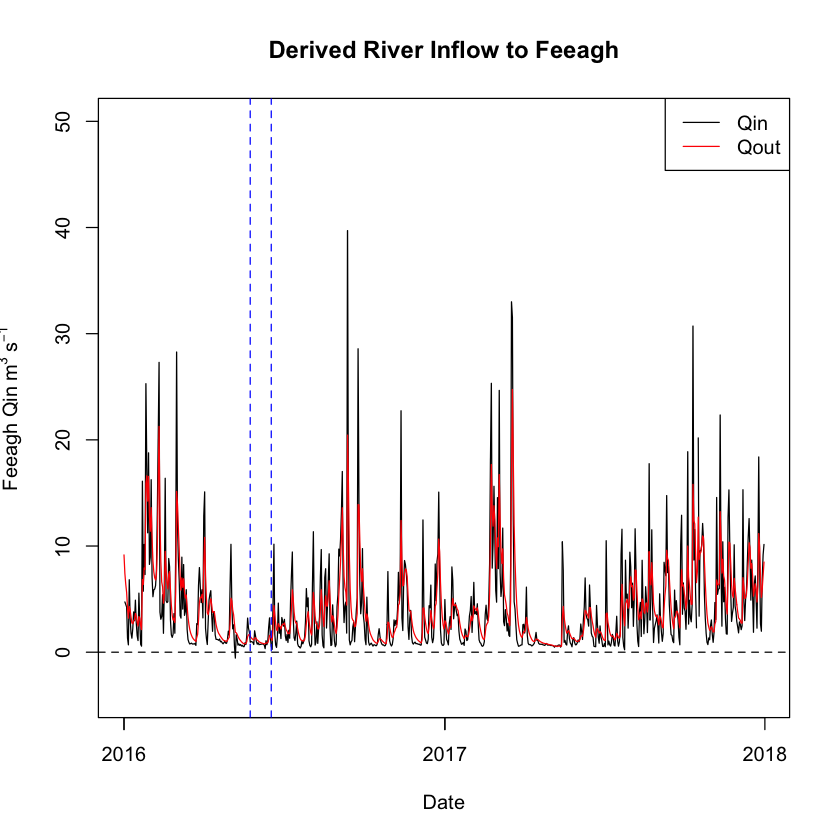

```python
setwd("~/Desktop/Temp_WD")
fee <- read.csv(file = 'Feeagh_water_bal 2016-2017_abbrev.csv')
#str(fee)
fee$date <- as.POSIXct(fee$date, format = "%Y-%m-%d %H:%M:%S", tz="UTC")

library("openair", lib.loc="~/anaconda3/lib/R/library")
feeD <- timeAverage(fee, avg.time="24 hour",start.date="2016-01-01 00:00:00")

# now for rain and evap sums:

rain_evapD <- aggregate(list(fee[,c(5,6)]),
                        list(date = cut(fee$date, "24 hours")), na.rm=FALSE,
                        sum)
feeD$rainmm <- rain_evapD$rainmm
feeD$evapmm <- rain_evapD$evapmm
#summary(feeD)

###################
###################
#1. Volumetric rate of direct precip on feeagh surface area

feeD$P <- (feeD$rainmm * 0.001 * 3113090)/86400 # get as m^3 s^-1

#2. Volumetric rate of direct evap from feeagh surface area

feeD$E <- (feeD$evapmm * 0.001 * 3113090)/86400 # get as m^3 s^-1

#3. Rate of storage change at surface (change in water level x surf.area)
dV_dt = NULL

for(i in 1:(length(feeD$feeHt)-1)) #

{dV_dt[i]=((feeD$feeHt[i+1] - feeD$feeHt[i])*3113090)/86400} #  where 3113090 is the surface area in m^2
dV_dt <- append(NA,dV_dt)
feeD <- cbind(feeD,dV_dt)

feeD$TotOut = feeD$Q_out + feeD$E # total loss of water from feeagh basin

# Using above water balance:

feeD$TotIn = feeD$dV_dt + feeD$TotOut

feeD$Q_in = feeD$TotIn - feeD$P # Net stream inflow is then the sum of total input - volumetric Precip

summary(feeD) ##!! look at summary statistics table output below, especially Q_in estimate (mean) ##!!

plot(feeD$date, feeD$Q_in, type="l", xlab="Date",ylim=c(-4,50), ylab=expression(paste("Feeagh Qin"~m^{3}~s^{-1})), main="Derived River Inflow to Feeagh")
lines(feeD$date, feeD$Q_out, col="red")
abline(v=as.POSIXct("2016-05-24"),col="blue",lty=2) # Mill Race dammed - may effect lake levels
abline(v=as.POSIXct("2016-06-17"),col="blue",lty=2) # Mill Race dammed - may effect lake levels
abline(h=0,lty=2)
legend('topright',legend = c('Qin','Qout'), lty = c(1,1),col = c('black','red'))
```

**Looking at the above summary of Q_in for Feeagh in the output table above - do these seem like reasonable values for discharge from the Black and Glenamong?** (bear in mind that the calculation method will encapsulate some of the discharge from e.g. the Cottage River/small streams that run into Feeagh, so the Qin reported here will probably be a little bit higher than that anticipated for just the Black and Glenamong)

There are a couple of things I am unsure about here that would be good to get some of your thoughts on:

1. Negative value for Qin (spring 2016). This is obviously not possible and is related to an event where a large quantity of rain fell in a very short period (I think 13.2 mm in one hour at one point) and when the lake level (and stream inflows) had been dropping significantly prior to this. The sudden volume flux from direct rainfall over Feeagh surface exceeds the instantaneous inflow (this is possible as the flow/lake level volume change lags rain events by several hours but obviously inflow can't be negative at any point). This may be one of the limitations of this method (but doesn't appear to happen often).
1. The Qin max flows exceed the Qout max flows which is curious - does this make sense? In one way, I think it does,if the storage capacity of the lake lets it act like a big buffer zone. When inflow >>> outflow, the lake level rises but there may be a bigger lag in the outflow of this water from the lake compared to the time taken for the level to rise due to inflow. The Mill Race and Salmon Leap are relatively narrow and constricted compared to the Black inflow, which may restrict the instantaneous rate of outflow by comparison. So if you get a huge discharge (vol of water per second) into Feeagh at the upper end then the buffering effect of the lake should reduce the outflow rate downstream by comparison (I think!). For steady-state conditions, the overall outflow will be equal (or greater), which it is averaged over time (4.2 vs 4.0 as outflow also includes direct Precip.). But perhaps the instantaneous flow rate can be greater for the unrestricted inflows, if Feeagh acts like a big low-pass filter for these incoming flows.

One way to potentially mitigate this is to use larger averaging intervals (2 or 3 days) or for daily resolution, bandpass filter the lake level timeseries with a cut-off frequency of ~3-5 days (see below). This is probably a good conservative place to start, as it represented the higher end of the time lag I saw between rain events and peak flows hence no negative values(it still shows slightly higher max inflows however so perhaps this is a reality of the system - the important thing is the mean **outflows** from Feeagh are slightly higher overall).

Okay let me know what ye think - does this make sense? I have used some simple assumptions here at times so perhaps you can help improve this and the catchment hydrology stuff is pretty new to me so I may have made some major mistake along the way!

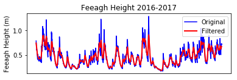

```python
import numpy as np
import matplotlib.pyplot as plt
H = np.genfromtxt('/Users/seankelly/Desktop/Temp_WD/fee_height.csv')

#H = H.astype(np.float) #...of floats
import scipy.signal as signal # IMPORT python signal processing tool

# First, design a low-pass Butterworth filter
N  = 1    # Filter order
#Wn = 0.04166 # Cutoff frequency of ~ 1 days
Wn = 0.00833 # Cutoff frequency of ~ 5 days
B, A = signal.butter(N, Wn, output='ba')

# Second, apply the filter
Hf = signal.filtfilt(B,A,H)

# Make plots
fig = plt.figure()
ax1 = fig.add_subplot(211)
plt.plot(H, 'b-')
plt.plot(Hf, 'r-',linewidth=2)
plt.ylabel("Feeagh Height (m)")
plt.legend(['Original','Filtered'])
plt.title("Feeagh Height 2016-2017")
ax1.axes.get_xaxis().set_visible(False)

#np.savetxt("/Users/seankelly/Desktop/Temp_WD/HtFiltered_5days.csv", Hf, delimiter=",")
```

```
      date                          mrHt             feeHt
 Min.   :2016-01-01 00:00:00   Min.   :0.04915   Min.   :0.1800
 1st Qu.:2016-07-01 12:00:00   1st Qu.:0.52806   1st Qu.:0.3123
 Median :2016-12-31 00:00:00   Median :0.60639   Median :0.4305
 Mean   :2016-12-31 00:00:00   Mean   :0.61253   Mean   :0.4579
 3rd Qu.:2017-07-01 12:00:00   3rd Qu.:0.69697   3rd Qu.:0.5641
 Max.   :2017-12-31 00:00:00   Max.   :1.08267   Max.   :1.1907
                               NA's   :61
     feeAs             rainmm           evapmm            Q_out
 Min.   :3113090   Min.   : 0.000   Min.   :-2.1086   Min.   : 0.5556
 1st Qu.:3113090   1st Qu.: 0.100   1st Qu.: 0.5882   1st Qu.: 1.6797
 Median :3113090   Median : 2.200   Median : 1.2122   Median : 3.1997
 Mean   :3113090   Mean   : 4.514   Mean   : 1.3219   Mean   : 4.2096
 3rd Qu.:3113090   3rd Qu.: 6.700   3rd Qu.: 1.9336   3rd Qu.: 5.6190
 Max.   :3113090   Max.   :56.200   Max.   : 5.1140   Max.   :24.7453
                   NA's   :1
    feeHt_f          feeHt_f3         feeHt_f5            P
 Min.   :0.1802   Min.   :0.1820   Min.   :0.1850   Min.   :0.000000
 1st Qu.:0.3133   1st Qu.:0.3232   1st Qu.:0.3285   1st Qu.:0.003603
 Median :0.4300   Median :0.4320   Median :0.4386   Median :0.079269
 Mean   :0.4579   Mean   :0.4580   Mean   :0.4581   Mean   :0.162658
 3rd Qu.:0.5673   3rd Qu.:0.5766   3rd Qu.:0.5796   3rd Qu.:0.241409
 Max.   :1.1487   Max.   :1.0034   Max.   :0.8932   Max.   :2.024950
                                                    NA's   :1
       E                dV_dt               TotOut           TotIn
 Min.   :-0.07598   Min.   :-8.962745   Min.   : 0.602   Min.   : 0.5008
 1st Qu.: 0.02119   1st Qu.:-1.395174   1st Qu.: 1.714   1st Qu.: 1.4848
 Median : 0.04368   Median :-0.351491   Median : 3.235   Median : 3.0564
 Mean   : 0.04763   Mean   :-0.001323   Mean   : 4.257   Mean   : 4.2480
 3rd Qu.: 0.06967   3rd Qu.: 0.664606   3rd Qu.: 5.651   3rd Qu.: 5.7634
 Max.   : 0.18426   Max.   :20.108000   Max.   :24.741   Max.   :27.9974
                    NA's   :1                            NA's   :1
      Q_in             dV_dtF
 Min.   : 0.2527   Min.   :-3.290844
 1st Qu.: 1.3722   1st Qu.:-0.645182
 Median : 2.9115   Median :-0.106592
 Mean   : 4.0803   Mean   :-0.002517
 3rd Qu.: 5.4743   3rd Qu.: 0.521325
 Max.   :27.2372   Max.   : 5.422686
 NA's   :2         NA's   :1
```

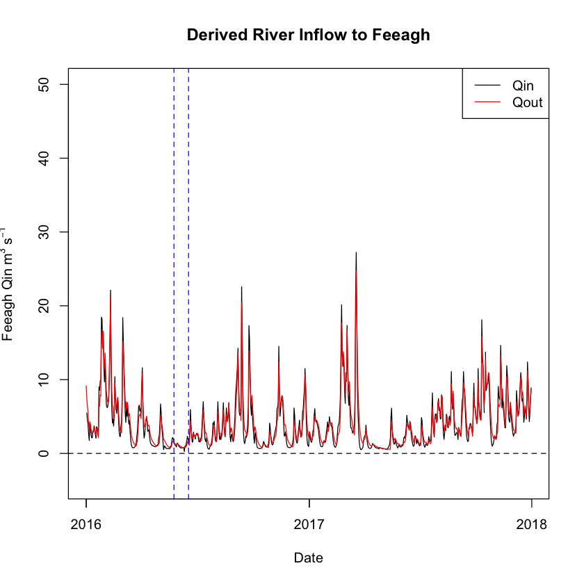

```python
###################
###################
## Repeat the water balance using a low-pass filtered Feeagh lake level

#3. Rate of storage change at surface (change in water level x surf.area)
dV_dtF = NULL

for(i in 1:(length(feeD$feeHt_f5)-1)) #

{dV_dtF[i]=((feeD$feeHt_f5[i+1] - feeD$feeHt_f5[i])*3113090)/86400} #  where 3113090 is the surface area in m^2
dV_dtF <- append(NA,dV_dtF)
feeD <- cbind(feeD,dV_dtF)

feeD$TotOut = feeD$Q_out + feeD$E # total loss of water from feeagh basin

# Using above water balance:

feeD$TotIn = feeD$dV_dtF + feeD$TotOut

feeD$Q_in = feeD$TotIn - feeD$P # Net stream inflow is then the sum of total input - volumetric Precip

summary(feeD) ##!! look at summary statistics table output below, especially Q_in estimate (mean) ##!!

plot(feeD$date, feeD$Q_in, type="l", xlab="Date",ylim=c(-4,50), ylab=expression(paste("Feeagh Qin"~m^{3}~s^{-1})), main="Derived River Inflow to Feeagh")
lines(feeD$date, feeD$Q_out, col="red")
abline(v=as.POSIXct("2016-05-24"),col="blue",lty=2) #Mill Race dammed
abline(v=as.POSIXct("2016-06-17"),col="blue",lty=2) #Mill Race dammed
abline(h=0,lty=2)
legend('topright',legend = c('Qin','Qout'), lty = c(1,1),col = c('black','red'))
```